# MAG 1 Project based on Dustmann et al. (2016, JEP)

January 5, 2024

## L’impact de l’immigration : pourquoi les études aboutissent-elles à des résultats si différents ?

Projet réalisé par :

- **ADJANOHOUN Brayann**
- **ADOUSSINGANDE Céline**
- **COMLAN Cybelle**
- **KOUKPONOU Sonagnon**

### **Question 1:** Revue théorique

*Question 1.1:* Brève comparaison des différentes approches discutées par les auteurs pour estimer l’impact des immigrants sur le marché du travail sur les autochtones

On peut distinguer trois approches :

- **L’approche par cellule nationale de compétences** : Il s’agit d’études qui utilisent la variation des flux d’immigrants à travers les cellules d’expérience en matière d’éducation au niveau national, comme par exemple dans Borjas (2003).
- **L’approche mixte** : elle prend en compte l’effet relatif de l’immigration d’un groupe de scolarité par rapport à un autre. Il s’agit principalement des études qui exploitent la variation du nombre total d’immigrants et les flux d’immigration entre les régions et entre les groupes de formation, comme par exemple dans Card (2001).
- **L’approche spatiale pure** : Elle récupère l’effet total de l’immigration qui, contrairement aux deux premières approches, prend en compte les complémentarités entre cellules de compétences et entre capital et travail.

**COMPARAISON:**

L’approche par cellule nationale de compétences tend à produire **des effets salariaux plus négatifs** pour les autochtones en réponse à l’immigration que l’approche mixte. Tandis que, les estimations obtenues à partir de l’approche spatiale pure varient considérablement en fonction du groupe de compétences étudiées.

- *Question 1.2:* Explication du déclassement des compétences observé chez les immigrants récents

Le « déclassement » se produit lorsque la position des immigrés sur le marché du travail, qui est généralement mesurée par le salaire ou la profession, est systématiquement inférieure à la position des autochtones ayant les mêmes niveaux d’éducation et d’expérience observés. Le déclassement signifie que les immigrants reçoivent des rendements inférieurs aux mêmes compétences mesurées que les autochtones lorsque ces compétences sont acquises dans leur pays d’origine.

- *Question 1.3:* Effet du déclassement des compétences sur les estimations

Procéder à la répartition des immigrés dans des groupes de compétences en fonction de leurs compétences mesurées peut conduire à des erreurs de classification et nuire sérieusement aux estimations des réponses salariales des autochtones à l’immigration. Par exemple dans le contexte américain, le déclassement peut surestimer l’impact négatif de l’immigration à la fois dans l’approche de cellule nationale de compétences et dans l’approche mixte, mais particulièrement dans l’approche de cellule nationale de compétences.

### **Question 2:** Tâches de réplication à partir du dataframe `census_acs_2000.dta`

**LES LIBRAIRIES UTILES**

```r
library(haven)
library(tidyverse)
library(stargazer)
```

**IMPORTATION DE LA BASE DE DONNEES ET EXTRACTION**

```r
path<-"C:/Users/ASUS/Desktop/"
read_dta(paste0(path, "census_acs_2000.dta")) %>%
  select(year, age, labforce, wkswork2, incwage, classwkr, educd, race,
         marst, empstat, bpld, yrimmig, sex, serial, occ) ->
  acs2000
```

Visualisation

```r
head(acs2000)
```

```
## # A tibble: 6 × 15
##   year       age     labforce wkswork2 incwage classwkr educd    race    marst
##   <dbl+lbl>  <dbl+l> <dbl+lb> <dbl+lb>   <dbl> <dbl+lb> <dbl+lb> <dbl+l> <dbl+l>
## 1 2000 [200… 66 [66] 2 [Yes,… 4 [40-4…    4000 2 [Work… 81 [Ass… 1 [Whi… 5 [Wid…
## 2 2000 [200… 40 [40] 2 [Yes,… 6 [50-5…   36700 2 [Work… 81 [Ass… 1 [Whi… 6 [Nev…
## 3 2000 [200… 51 [51] 2 [Yes,… 6 [50-5…   54000 2 [Work… 62 [Hig… 1 [Whi… 1 [Mar…
## 4 2000 [200… 48 [48] 1 [No, … 1 [1-13…     900 2 [Work… 62 [Hig… 1 [Whi… 1 [Mar…
## 5 2000 [200… 19 [19] 2 [Yes,… 2 [14-2…    2000 2 [Work… 62 [Hig… 1 [Whi… 6 [Nev…
## 6 2000 [200… 17 [17] 1 [No, … 0 [N/A]        0 0 [N/A]  62 [Hig… 1 [Whi… 6 [Nev…
## # ℹ 6 more variables: empstat <dbl+lbl>, bpld <dbl+lbl>, yrimmig <dbl+lbl>,
## #   sex <dbl+lbl>, serial <dbl>, occ <dbl>
```

**ANALYSE EXPLORATOIRE: PRELIMINAIRES**

- Délimitation de l’échantillon de travailleurs i.e la population active celle agée entre 18 à 65 ans

```r
acs2000 %>%
  filter(age >=18 & age <=65 & labforce == 2,classwkr == 2) -> acs2000
```

- Création et recodage de variables :

*weeks* : Cette variable est calculée en multipliant différents multiplicateurs par les catégories de la variable `wkswork2`.

*lnw* : Cette variable est calculée avec le logarithme naturel de la variable `incwage` diviser par la variable `weeks`.

```r
acs2000 %>%
  mutate(weeks = 7 * (wkswork2 == 1) + 20 * (wkswork2 == 2) +
           33 * (wkswork2 == 3) +
           43.5 * (wkswork2 == 4) + 48.5 * (wkswork2 == 5) +
           51 * (wkswork2 == 6)) %>%
  mutate(lnw = log(incwage / weeks)) %>%
  filter(!is.na(lnw), lnw != -Inf, lnw != Inf) ->
  acs2000
```

*foreign* : la nouvelle variable prendra la valeur “TRUE” si la valeur de `bpld` est supérieure ou égale à 15000.

*immclass* : Ajoute une nouvelle variable initialisée à `NA` puis modifie la valeur de la colonne `immclass` en 1 si la valeur de la colonne `foreign` est égale à 1 et si la différence entre les valeurs des colonnes `year` et `yrimmig` est inférieure ou égale à 2.

Modifie la valeur de la colonne `immclass` en 2 si la valeur de la colonne `foreign` est égale à 1 et si la différence entre les valeurs des colonnes `year` et `yrimmig` est supérieure à 2 et inférieure ou égale à 5, etc.

```r
acs2000 %>%
  mutate(foreign = (bpld>=15000),
         immclass = case_when(foreign==1 & year-yrimmig<=2 ~ 1,
                              foreign==1 & year-yrimmig> 2 & year-yrimmig<=5 ~ 2,
                              foreign==1 & year-yrimmig> 5 & year-yrimmig<=10 ~ 3,
                              foreign==1 & year-yrimmig> 10 & !is.na(year-yrimmig) ~ 4
         ),
  agecat= case_when(age >= 18 & age <= 25 ~ 1,
                             age > 25 & age <= 35 ~ 2,
                             age > 35 & age <= 45 ~ 3,
                             age > 45 & age <= 55 ~ 4,
                             age > 55 & age <= 65 ~ 5,
                             TRUE ~ NA_real_
          ))-> acs2000
```

*Schooling* : La première mutation initialise la variable `schooling` à 0 par défaut. Ensuite les codes qui suivent mettent à jour la colonne `schooling` dans le tableau de données *acs2000* en remplaçant les zéros en fonction des valeurs de la colonne `educd` dans chaque ligne.

*pe* : L’expérience professionnelle qui est donnée par la différence entre `age` et la somme de 6 et `schooling`.

```r
acs2000 %>%
  mutate(schooling = 0) %>%
  mutate(schooling = ifelse(educd == 10, 2, schooling)) %>%
  mutate(schooling = ifelse(educd == 13, 2.5, schooling)) %>%
  mutate(schooling = ifelse(educd == 14, 1, schooling)) %>%
  mutate(schooling = ifelse(educd == 15, 2, schooling)) %>%
  mutate(schooling = ifelse(educd == 16, 3, schooling)) %>%
  mutate(schooling = ifelse(educd == 17, 4, schooling)) %>%
  mutate(schooling = ifelse(educd == 20, 6.5,schooling)) %>%
  mutate(schooling = ifelse(educd == 21, 5.5, schooling)) %>%
  mutate(schooling = ifelse(educd == 22, 5, schooling)) %>%
  mutate(schooling = ifelse(educd == 23, 6, schooling)) %>%
  mutate(schooling = ifelse(educd == 25, 7, schooling)) %>%
  mutate(schooling = ifelse(educd == 24, 7.5, schooling)) %>%
  mutate(schooling = ifelse(educd == 26, 8, schooling)) %>%
  mutate(schooling = ifelse(educd == 30, 9, schooling)) %>%
  mutate(schooling = ifelse(educd == 40, 10, schooling)) %>%
  mutate(schooling = ifelse(educd == 50 | educd == 61, 11, schooling)) %>%
  mutate(schooling = ifelse(educd == 60 | (educd >= 62 & educd <= 64), 12, schooling)) %>%
  mutate(schooling = ifelse(educd >= 65 & educd <= 71, 13, schooling)) %>%
  mutate(schooling = ifelse(educd >= 80 & educd <= 90, 14, schooling)) %>%
  mutate(schooling = ifelse(educd == 90, 15, schooling)) %>%
  mutate(schooling = ifelse(educd == 100 | educd == 101, 16, schooling)) %>%
  mutate(schooling = ifelse(educd == 110, 17, schooling)) %>%
  mutate(schooling = ifelse(educd == 111 | educd == 114, 18, schooling)) %>%
  mutate(schooling = ifelse(educd == 112, 19, schooling)) %>%
  mutate(schooling = ifelse(educd == 113 | educd > 114, 20, schooling)) %>%
  mutate(pe = as.integer(age - 6 - schooling))  ->
  acs2000
```

L’instruction ci-dessous filtre le dataframe en gardant uniquement les lignes où `lnw` n’est pas NA et où `pe` est supérieur ou égal à 1 et inférieur ou égal à 40. En d’autres termes, les lignes avec des valeurs manquantes de `lnw` sont exclues et seules les lignes avec des valeurs de `pe` comprises entre 1 et 40 sont gardées

```r
acs2000 %>%
  filter(!is.na(lnw), pe >= 1 & pe <= 40) ->
  acs2000
```

- Affichage des colonnes en horizontale avec leurs types respectifs

```r
glimpse(acs2000)
```

```
## Rows: 146,577
## Columns: 22
## $ year      <dbl+lbl> 2000, 2000, 2000, 2000, 2000, 2000, 2000, 2000, 2000, 20…
## $ age       <dbl+lbl> 40, 51, 19, 47, 46, 19, 37, 49, 39, 36, 26, 24, 57, 54, …
## $ labforce  <dbl+lbl> 2, 2, 2, 2, 2, 2, 2, 2, 2, 2, 2, 2, 2, 2, 2, 2, 2, 2, 2,…
## $ wkswork2  <dbl+lbl> 6, 6, 2, 2, 6, 3, 6, 6, 6, 6, 6, 6, 6, 6, 4, 6, 6, 6, 6,…
## $ incwage   <dbl> 36700, 54000, 2000, 8000, 28000, 11000, 52000, 125000, 32000…
## $ classwkr  <dbl+lbl> 2, 2, 2, 2, 2, 2, 2, 2, 2, 2, 2, 2, 2, 2, 2, 2, 2, 2, 2,…
## $ educd     <dbl+lbl>  81,  62,  62,  62,  81,  62, 101, 114,  81, 116,  71, 1…
## $ race      <dbl+lbl> 1, 1, 1, 1, 1, 1, 1, 1, 1, 1, 1, 1, 1, 1, 1, 1, 1, 1, 1,…
## $ marst     <dbl+lbl> 6, 1, 6, 4, 1, 6, 1, 1, 6, 6, 1, 1, 1, 1, 1, 6, 6, 2, 1,…
## $ empstat   <dbl+lbl> 1, 1, 1, 2, 1, 1, 1, 1, 1, 1, 1, 1, 1, 1, 1, 1, 1, 1, 1,…
## $ bpld      <dbl+lbl>  1700,  4800,  4800,  2100, 45300,  5300, 52200,   600, …
## $ yrimmig   <dbl+lbl>    0,    0,    0,    0, 1990,    0, 1983,    0,    0,   …
## $ sex       <dbl+lbl> 1, 1, 1, 1, 2, 1, 2, 1, 1, 2, 1, 2, 1, 1, 2, 1, 1, 1, 2,…
## $ serial    <dbl> 1, 2, 2, 3, 5, 5, 7, 7, 9, 11, 13, 13, 14, 15, 15, 16, 16, 1…
## $ occ       <dbl> 721, 803, 936, 16, 215, 633, 330, 260, 720, 201, 961, 231, 4…
## $ weeks     <dbl> 51.0, 51.0, 20.0, 20.0, 51.0, 33.0, 51.0, 51.0, 51.0, 51.0, …
## $ lnw       <dbl> 6.578706, 6.964914, 4.605170, 5.991465, 6.308134, 5.809143, …
## $ foreign   <lgl> FALSE, FALSE, FALSE, FALSE, TRUE, FALSE, TRUE, FALSE, FALSE,…
## $ immclass  <dbl> NA, NA, NA, NA, 3, NA, 4, NA, NA, NA, NA, NA, NA, NA, NA, 2,…
## $ agecat    <dbl> 3, 4, 1, 4, 4, 1, 3, 4, 3, 3, 2, 1, 5, 4, 4, 1, 1, 4, 2, 1, …
## $ schooling <dbl> 14, 12, 12, 12, 14, 12, 16, 18, 14, 20, 13, 16, 16, 12, 13, …
## $ pe        <int> 20, 33, 1, 29, 26, 1, 15, 25, 19, 10, 7, 2, 35, 36, 28, 4, 4…
```

*Question 2.1:* Explorons la présence d’un déclassement des compétences, en estimant les regressions salariales incluant le niveau de scolarité comme variable catégorielle et l’interaction entre le niveau de scolarité et l’âge.

```r
modf <-lnw ~ educd+age+I(age^2)+ sex+educd:age + foreign

reg1 <- lm(modf, data=acs2000, subset=(foreign==0 |immclass==1))
reg2 <- lm(modf, data=acs2000, subset=(foreign==0 |immclass==2))
reg3 <- lm(modf, data=acs2000, subset=(foreign==0 |immclass==3))
reg4 <- lm(modf, data=acs2000, subset=(foreign==0 |immclass==4))

stargazer(reg1,reg2,reg3,reg4,
          dep.var.caption="0-2 years 3-5 years 6-10 years more than 10 years",dep.var.labels="",
          omit.table.layout = "n", star.cutoffs = NA,
          keep.stat=c("n", "rsq"),no.space=TRUE,
          keep=c("foreignTRUE"),
          header=TRUE,
          title="Table replication", type="text"
)
```

```
##
## Table replication
## =================================================================
##               0-2 years 3-5 years 6-10 years more than 10 years
##              ----------------------------------------------------
##
##                   (1)          (2)          (3)          (4)
## -----------------------------------------------------------------
## foreign         -0.120        -0.115       -0.035       0.004
##                 (0.018)      (0.017)      (0.013)      (0.007)
## -----------------------------------------------------------------
## Observations    131,199      131,483      132,562      140,382
## R2               0.305        0.305        0.305        0.303
## =================================================================
```

**COMMENTAIRE ET INTERPRETATION DU TABLEAU DE REGRESSION**

La ligne `foreign` donne les coefficients estimés pour la variable foreign dans chaque catégorie d’immigrants. Les valeurs indiquent comment le log du salaire (lnw) change en réponse à un changement d’une unité dans la variable foreign.Ainsi:

- Model 1

Interprétation : l’augmentation d’une unité dans la variable foreign est associée à une diminution de 0.120 dans le log du salaire (lnw) pour les individus de la catégorie “0-2 years” par rapport aux natifs (non-immigrants) ou étrangers sans spécification de durée.

- Model 2

Interprétation : L’augmentation d’une unité dans la variable foreign entraine une diminution de 0.115 dans le log du salaire (lnw) pour les individus de la catégorie “3-5 years” par rapport aux natifs (non-immigrants) ou étrangers sans spécification de durée.

- Model 4

Une unité d’augmentation dans la variable foreign est associée à une augmentation de 0.004 dans le log du salaire (lnw) pour les individus de la catégorie “more than 10 years” par rapport aux natifs (non-immigrants) ou étrangers sans spécification de durée.

*Remarques :*

Les coefficients négatifs indiquent une relation négative entre la variable foreign et le log du salaire. Cela suggère que, en moyenne, les personnes étrangères ont tendance à avoir des salaires inférieurs par rapport aux natifs ou aux étrangers sans spécification de durée.

La magnitude des coefficients donne une idée de l’ampleur de l’effet de la variable foreign sur le log du salaire dans chaque catégorie.

Il est important de noter que ces interprétations sont basées sur l’hypothèse que les autres variables du modèle restent constantes.

**PREDICTION DU LOGARITHME DES SALAIRES**

```r
acs2000$lnw_pred <- NA
acs2000$sigma <- NA

acs2000$in_reg <- (acs2000$sex == 1 & acs2000$foreign == 0)
mod <- lm(lnw ~ foreign + age + educd + educd*age,
          data=acs2000, subset=in_reg)
acs2000$sigma[acs2000$in_reg] <- (mod$residuals)^2
acs2000$lnw_pred[acs2000$sex == 1] <- predict(mod, acs2000[acs2000$sex == 1,])
```

```r
acs2000 %>% arrange(serial) -> acs2000
set.seed(1234)

for (i in min(acs2000$agecat):max(acs2000$agecat)) {
  for (k in 1:2) {
    for (j in min(acs2000$educd):max(acs2000$educd) ) {
      acs2000$in_reg <- (acs2000$agecat==i & acs2000$sex==k & acs2000$educd==j)
      N = sum(acs2000$in_reg)
      if (N>0) {
        sdS = sqrt(mean(acs2000$sigma[acs2000$in_reg], na.rm=TRUE))
        # cat(i, k, j, "N=",N, "  ", sdS, "\n")
        acs2000$lnw_pred[acs2000$in_reg] = acs2000$lnw_pred[acs2000$in_reg] +
          rnorm(N,0,sdS)
      }
    }
  }
}

acs2000 %>%
  filter(!is.na(lnw_pred)) %>%
  mutate(lnw_pred = ifelse(foreign==0, lnw,lnw_pred)) ->
  acs2000
```

*Question 2.2:* Computation of the percentile ranks in actual and predicted wage distribution

- Calcule des rangs centiles pour les salaires réels

```r
acs2000 <- acs2000 %>%
  mutate(x = (foreign==0)) %>%
  arrange(lnw) %>% # sorting
  mutate(rank = cumsum(x) ) %>% # somme cumulée de l'indicateur qui prouve qu'on n'est pas immigrée
  mutate(rank = rank / max(rank)) %>% # normalisation to [0,1]
  mutate(immpos = ifelse(log(rank/(1-rank)) < Inf, log(rank/(1-rank)), NA)) # première transformation des rangs par la transformation logarithmique

# estimation de la densité
dens_imm =density(acs2000$immpos[acs2000$foreign == 1])

# Retransformation
dens_imm$x2 <- exp(dens_imm$x) / (1 + exp(dens_imm$x))
```

- Calcule des rangs centiles pour les salaires prédits

Il s’agit de Calculer la variable `Foreign predicted` et d’appliquer la meme pocédure comme pour pour `lnw_pred`. Voici la procédure que nous proposons :

```r
modele <- glm(foreign ~ bpld + immclass, data = acs2000, family = "binomial")# Construction du modèle de régression logistique

acs2000 <- acs2000 %>%
  mutate(foreign_pred = predict(modele, newdata = ., type = "response")) %>%
  mutate(foreign_pred = ifelse(is.na(foreign_pred), 0, foreign_pred)) %>%
  mutate(foreign_pred = as.logical(foreign_pred))

acs2000 <- acs2000 %>%
  mutate(y = (foreign_pred == 0)) %>%
  arrange(lnw_pred) %>% # sorting
  mutate(rank_pred = cumsum(y)) %>%
  mutate(rank_pred = rank_pred / max(rank_pred)) %>%
  mutate(immpos_pred = ifelse(log(rank_pred/(1-rank_pred)) < Inf, log(rank_pred/(1-rank_pred)), NA))

# Estimation de la densité :
dens_imm_pred= density(acs2000$immpos_pred[acs2000$foreign_pred == 1])

#transformation
dens_imm_pred$y2 <- exp(dens_imm_pred$y) / (1 + exp(dens_imm_pred$y))
```

**Cependant en optant pour la procédure ci-dessus, nous avons rencontré des difficultés dans le calcul de la variable `Foreign predicted`.**

**Voici le code similaire que nous avons finalement utilisé pour calculer les rangs centiles prédits:**

```r
#une autre méthode que voici :

ecdf_lnwpr <- ecdf(acs2000$lnw)# Création de la fonction de distribution cumulative empirique (ECDF)
centiles_predi <- ecdf_lnwpr(seq(min(acs2000$lnw_pred), max(acs2000$lnw_pred), length.out = 101))
centiles_predi = centiles_predi[1:100]
rang_p <- log(centiles_predi /(1-centiles_predi))

# Estimation de la densité de la distribution des rangs transformés :
dens_imm1 <- density(rang_p)
# Puis la rétransformation
inv_transform <- function(x) {return (exp(x) / (1 +exp(x)))}

x1= inv_transform(dens_imm1$x)
dens1=density(x1)
```

- Le graphique 1.A :

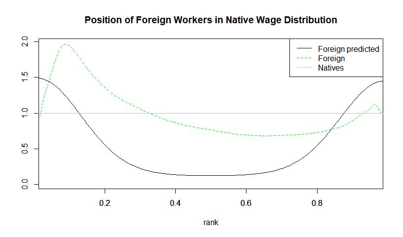

```r
# Tracer la première graphique
plot(dens_imm$x2,
     dens_imm$y /(dens_imm$x2 * (1-dens_imm$x2)), type = "l", lty = 2,ylab="", xlab="rank", col = "green", xlim = c(0.05, 0.95))

title("Position of Foreign Workers in Native Wage Distribution")

# Tracer la deuxième graphique # A corriger
lines(dens1, type="l",
      ylab="", xlab="rank", col = "black")
# Tracer la troisième graphique
abline(h = 1, col = "grey")
axis(1, at = c(0.2, 0.4, 0.6, 0.8))
# Ajouter la légende
legend("topright", legend = c("Foreign predicted", "Foreign", "Natives"),
       col = c("black", "green", "grey"), lty = c(1, 2, 1))
```

**Pour avoir laxe des ordonnées comme exactement dans larticle nous avons fait recours au code suivant après le premier graphique. Toutefois, cela n’a pas marché et doit faire objet de correction**

```r
y_vals <- c(0.8, 1.0, 1.2, 1.4, 1.6)
axis(2, at = y_vals, labels = y_vals)
```

```r
# Tracer le graphique pour les immigrants travailleurs


# Arrival 3-10 years(immclass == 2 | immclass == 3)

acs2000 <- acs2000 %>%
  mutate(x = (immclass == 2 | immclass == 3)) %>%
  mutate(RAnk = cumsum(x) ) %>% # somme cumulée de l'indicateur qui prouve qu'on n'est pas immigrée
  mutate(RAnk = RAnk / max(RAnk)) %>% # normalisation to [0,1]
  mutate(IMmpos = ifelse(log(RAnk/(1-RAnk)) < Inf, log(RAnk/(1-RAnk)), NA)) # première transformation des rangs par la transformation logarithmique

# Densité
DEns_imm =density(acs2000$immpos[acs2000$x])

#Retransformation

DEns_imm$x2 <- exp(dens_imm$x) / (1 + exp(dens_imm$x))

#Tracé des courbes
# Tracer la première courbe
plot(DEns_imm$x2,
     DEns_imm$y /(DEns_imm$x2 * (1-DEns_imm$x2)), type = "l", lty = 2, #lwd=1,
     ylab="", xlab="rank", col = "orange", xlim = c(0.02, 0.95))

# Ajouter la deuxième courbe
lines(dens_imm$x2,
      dens_imm$y /(dens_imm$x2 * (1-dens_imm$x2)), type = "l", lty = 2, #lwd=1,
      col = "green")

# Tracer la troisième graphique
abline(h = 1, col = "grey")

axis(1, at = c(0.2, 0.4, 0.6, 0.8))

# Ajouter la légende
legend("topright", legend = c("Arrival <= 2 years", "Arrival 3-10 years", "Natives"),
       +        col = c("green", "orange","grey"), lty = c(1, 2,1))
```

[output not shown]

### **Question 3 :** Extraction des variables pertinentes d’ipums USA, et comparaison de l’extrait de données aux principaux résultats de régression.census_acs_2000.dta

Dans cette partie nous nous sommes rendus sur le site https://usa.ipums.org pour sélectionner les variables pertinentes et constituer l’échantillon de données comme l’illustre les images ci dessous :

[figure not shown]

```r
library(haven)
library(tidyverse)
library(stargazer)
library(dplyr)
library(ggplot2)
library('ipumsr')
```

**REPLICATION DE ENSEMBLE DES CODES PRECEDENTS ADAPTES A LA BASE IPUMS EXTRAITES**

```r
# Spécification du chemin d'accès au fichier .xml
path_xml <-"C:/Users/ASUS/Desktop/usa_00003.dat/usa_00003.xml"

# Lecture du fichier .xml
ddi <- read_ipums_ddi(path_xml)

# Spécification du chemin d'accès au fichier .dat
path_dat <- "C:/Users/ASUS/Desktop/usa_00003.dat/usa_00003.dat"

# Lecture des données
usa_00003 <- read_ipums_micro(ddi, data_file = path_dat)
usa_00003%>%
  select(YEAR, AGE, LABFORCE, WKSWORK2 , INCWAGE , CLASSWKR , EDUCD , RACE ,
         MARST , EMPSTAT , BPLD , YRIMMIG , SEX , SERIAL , OCC ) ->
  usa_00003
```

**ANALYSE EXPLORATOIRE avec usa_00003 : PRELIMINAIRES**

```r
#Délimitation de l'échantillon
usa_00003 %>%
  filter(AGE >=18 & AGE <=65 & LABFORCE == 2,CLASSWKR == 2) ->
  usa_00003

# Création et recodage  des variables :
# WEEKS, LNW
usa_00003 %>%
  mutate(WEEKS  = 7 * (WKSWORK2 == 1) + 20 * (WKSWORK2 == 2) +
           33 * (WKSWORK2 == 3) +
           43.5 * (WKSWORK2 == 4) + 48.5 * (WKSWORK2 == 5) +
           51 * (WKSWORK2 == 6)) %>%
  mutate( LNW = log(INCWAGE / WEEKS)) %>%
  filter(!is.na(LNW), LNW != -Inf, LNW != Inf) ->
  usa_00003

#FOREIGN ,IMMCLASS
usa_00003 %>%
  mutate(FOREIGN  = (BPLD >=15000),
         IMMCLASS = case_when(FOREIGN==1 & YEAR-YRIMMIG<=2 ~ 1,
                              FOREIGN==1 & YEAR-YRIMMIG> 2 & YEAR-YRIMMIG<=5 ~ 2,
                              FOREIGN==1 & YEAR-YRIMMIG> 5 & YEAR-YRIMMIG<=10 ~ 3,
                              FOREIGN==1 & YEAR-YRIMMIG> 10 & !is.na(YEAR-YRIMMIG) ~ 4
         ),
         AGECAT  = case_when(AGE  >= 18 & AGE <= 25 ~ 1,
                             AGE > 25 & AGE <= 35 ~ 2,
                             AGE > 35 & AGE <= 45 ~ 3,
                             AGE > 45 ~ 4,
                             TRUE ~ NA_real_
         ))-> usa_00003

usa_00003 %>%
  mutate(SCHOOLING  = 0) %>%
  mutate(SCHOOLING = ifelse(EDUCD == 10, 2, SCHOOLING)) %>%
  mutate(SCHOOLING = ifelse(EDUCD == 13, 2.5, SCHOOLING)) %>%
  mutate(SCHOOLING = ifelse(EDUCD == 14, 1, SCHOOLING)) %>%
  mutate(SCHOOLING = ifelse(EDUCD == 15, 2, SCHOOLING)) %>%
  mutate(SCHOOLING = ifelse(EDUCD == 16, 3, SCHOOLING)) %>%
  mutate(SCHOOLING = ifelse(EDUCD == 17, 4, SCHOOLING)) %>%
  mutate(SCHOOLING = ifelse(EDUCD == 20, 6.5,SCHOOLING)) %>%
  mutate(SCHOOLING = ifelse(EDUCD == 21, 5.5, SCHOOLING)) %>%
  mutate(SCHOOLING = ifelse(EDUCD == 22, 5, SCHOOLING)) %>%
  mutate(SCHOOLING = ifelse(EDUCD == 23, 6, SCHOOLING)) %>%
  mutate(SCHOOLING = ifelse(EDUCD == 25, 7, SCHOOLING)) %>%
  mutate(SCHOOLING = ifelse(EDUCD == 24, 7.5, SCHOOLING)) %>%
  mutate(SCHOOLING = ifelse(EDUCD == 26, 8, SCHOOLING)) %>%
  mutate(SCHOOLING = ifelse(EDUCD == 30, 9, SCHOOLING)) %>%
  mutate(SCHOOLING = ifelse(EDUCD == 40, 10, SCHOOLING)) %>%
  mutate(SCHOOLING = ifelse(EDUCD == 50 | EDUCD == 61, 11, SCHOOLING)) %>%
  mutate(SCHOOLING = ifelse(EDUCD == 60 | (EDUCD >= 62 & EDUCD <= 64), 12, SCHOOLING)) %>%
  mutate(SCHOOLING = ifelse(EDUCD >= 65 & EDUCD <= 71, 13, SCHOOLING)) %>%
  mutate(SCHOOLING = ifelse(EDUCD >= 80 & EDUCD <= 90, 14, SCHOOLING)) %>%
  mutate(SCHOOLING = ifelse(EDUCD == 90, 15, SCHOOLING)) %>%
  mutate(SCHOOLING = ifelse(EDUCD == 100 | EDUCD == 101, 16, SCHOOLING)) %>%
  mutate(SCHOOLING = ifelse(EDUCD == 110, 17, SCHOOLING)) %>%
  mutate(SCHOOLING = ifelse(EDUCD == 111 | EDUCD == 114, 18, SCHOOLING)) %>%
  mutate(SCHOOLING = ifelse(EDUCD == 112, 19, SCHOOLING)) %>%
  mutate(SCHOOLING = ifelse(EDUCD == 113 | EDUCD > 114, 20, SCHOOLING)) %>%
  mutate(PE = as.integer(AGE - 6 - SCHOOLING))  ->
  usa_00003

usa_00003 %>%
  filter(!is.na(LNW), PE >= 1 & PE <= 40) ->
  usa_00003

#affichage de la base
glimpse(usa_00003)
```

```
## Rows: 146,577
## Columns: 22
## $ YEAR      <int> 2000, 2000, 2000, 2000, 2000, 2000, 2000, 2000, 2000, 2000, …
## $ AGE       <int+lbl> 40, 51, 19, 47, 46, 19, 37, 49, 39, 36, 26, 24, 57, 54, …
## $ LABFORCE  <int+lbl> 2, 2, 2, 2, 2, 2, 2, 2, 2, 2, 2, 2, 2, 2, 2, 2, 2, 2, 2,…
## $ WKSWORK2  <int+lbl> 6, 6, 2, 2, 6, 3, 6, 6, 6, 6, 6, 6, 6, 6, 4, 6, 6, 6, 6,…
## $ INCWAGE   <dbl+lbl>  36700,  54000,   2000,   8000,  28000,  11000,  52000, …
## $ CLASSWKR  <int+lbl> 2, 2, 2, 2, 2, 2, 2, 2, 2, 2, 2, 2, 2, 2, 2, 2, 2, 2, 2,…
## $ EDUCD     <int+lbl> 81, 62, 62, 62, 81, 62, 101, 114, 81, 116, 71, 101, 101,…
## $ RACE      <int+lbl> 1, 1, 1, 1, 1, 1, 1, 1, 1, 1, 1, 1, 1, 1, 1, 1, 1, 1, 1,…
## $ MARST     <int+lbl> 6, 1, 6, 4, 1, 6, 1, 1, 6, 6, 1, 1, 1, 1, 1, 6, 6, 2, 1,…
## $ EMPSTAT   <int+lbl> 1, 1, 1, 2, 1, 1, 1, 1, 1, 1, 1, 1, 1, 1, 1, 1, 1, 1, 1,…
## $ BPLD      <int+lbl> 1700, 4800, 4800, 2100, 45300, 5300, 52200, 600, 3100, 4…
## $ YRIMMIG   <int+lbl> 0, 0, 0, 0, 1990, 0, 1983, 0, 0, 0, 0, 0, 0, 0, 0, 1995,…
## $ SEX       <int+lbl> 1, 1, 1, 1, 2, 1, 2, 1, 1, 2, 1, 2, 1, 1, 2, 1, 1, 1, 2,…
## $ SERIAL    <dbl> 1, 2, 2, 3, 5, 5, 7, 7, 9, 11, 13, 13, 14, 15, 15, 16, 16, 1…
## $ OCC       <int+lbl> 721, 803, 936, 16, 215, 633, 330, 260, 720, 201, 961, 23…
## $ WEEKS     <dbl> 51.0, 51.0, 20.0, 20.0, 51.0, 33.0, 51.0, 51.0, 51.0, 51.0, …
## $ LNW       <dbl> 6.578706, 6.964914, 4.605170, 5.991465, 6.308134, 5.809143, …
## $ FOREIGN   <lgl> FALSE, FALSE, FALSE, FALSE, TRUE, FALSE, TRUE, FALSE, FALSE,…
## $ IMMCLASS  <dbl> NA, NA, NA, NA, 3, NA, 4, NA, NA, NA, NA, NA, NA, NA, NA, 2,…
## $ AGECAT    <dbl> 3, 4, 1, 4, 4, 1, 3, 4, 3, 3, 2, 1, 4, 4, 4, 1, 1, 4, 2, 1, …
## $ SCHOOLING <dbl> 14, 12, 12, 12, 14, 12, 16, 18, 14, 20, 13, 16, 16, 12, 13, …
## $ PE        <int> 20, 33, 1, 29, 26, 1, 15, 25, 19, 10, 7, 2, 35, 36, 28, 4, 4…
```

**TACHE DE REPLICATION 2**

```r
MODF <-LNW ~ EDUCD +AGE+I(AGE^2)+ SEX+EDUCD:AGE + FOREIGN

REG2 <- lm(MODF, data=usa_00003, subset=(FOREIGN==0 |IMMCLASS==1))
REG3 <- lm(MODF, data=usa_00003, subset=(FOREIGN==0 |IMMCLASS==2))
REG4 <- lm(MODF, data=usa_00003, subset=(FOREIGN==0 |IMMCLASS==3))
REG5 <- lm(MODF, data=usa_00003, subset=(FOREIGN==0 |IMMCLASS==4))

stargazer(REG2,REG3,REG4,REG5,
          dep.var.caption="0-2 years 3-5 years 6-10 years more than 10 years",dep.var.labels="",
          omit.table.layout = "n", star.cutoffs = NA,
          keep.stat=c("n", "rsq"),no.space=TRUE,
          keep=c("FOREIGNTRUE"),
          header=TRUE,
          title="Table replication",type="text"
)
```

```
##
## Table replication
## =================================================================
##               0-2 years 3-5 years 6-10 years more than 10 years
##              ----------------------------------------------------
##
##                   (1)          (2)          (3)          (4)
## -----------------------------------------------------------------
## FOREIGN         -0.120        -0.115       -0.035       0.004
##                 (0.018)      (0.017)      (0.013)      (0.007)
## -----------------------------------------------------------------
## Observations    131,199      131,483      132,562      140,382
## R2               0.305        0.305        0.305        0.303
## =================================================================
```

```r
usa_00003$LNW_PRED <- NA
usa_00003$SIGMA <- NA

usa_00003$IN_REG <- (usa_00003$SEX == 1 & usa_00003$FOREIGN == 0)
MOD <- lm(LNW ~ FOREIGN + AGE + EDUCD + EDUCD*AGE,
          data=usa_00003, subset=IN_REG)
usa_00003$SIGMA[usa_00003$IN_REG] <- (MOD$residuals)^2
usa_00003$LNW_PRED[usa_00003$SEX == 1] <- predict(MOD, usa_00003[usa_00003$SEX == 1,])

usa_00003 %>% arrange(SERIAL) -> usa_00003
set.seed(1234)

for (i in min(usa_00003$AGECAT):max(usa_00003$AGECAT)) {
  for (k in 1:2) {
    for (j in min(usa_00003$EDUCD):max(usa_00003$EDUCD) ) {
      usa_00003$IN_REG <- (usa_00003$AGECAT==i & usa_00003$SEX==k & usa_00003$EDUCD==j)
      N = sum(usa_00003$IN_REG)
      if (N>0) {
        sdS = sqrt(mean(usa_00003$SIGMA[usa_00003$IN_REG], na.rm=TRUE))
        # cat(i, k, j, "N=",N, "  ", sdS, "\n")
        usa_00003$LNW_PRED[usa_00003$IN_REG] = usa_00003$LNW_PRED[usa_00003$IN_REG] +
          rnorm(N,0,sdS)
      }
    }
  }
}

usa_00003 %>%
  filter(!is.na(LNW_PRED)) %>%
  mutate(LNW_PRED = ifelse(FOREIGN==0, LNW,LNW_PRED)) ->
  usa_00003
```

Question 2 avec `usa_00003`

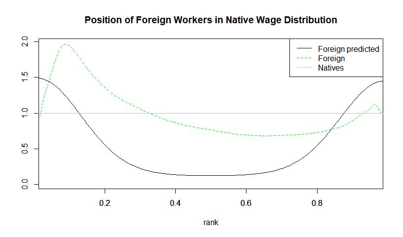

```r
#Calcul des rang centiles
usa_00003 <- usa_00003 %>%
  mutate(x = (FOREIGN==0)) %>%
  arrange(LNW) %>% # sorting
  mutate(RANK = cumsum(x) ) %>%
  mutate(RANK = RANK / max(RANK)) %>% # normalisation to [0,1]
  mutate(IMMPOS = ifelse(log(RANK/(1-RANK)) < Inf, log(RANK/(1-RANK)), NA))

#estimation de la densité
DENS_IMM =density(usa_00003$IMMPOS[usa_00003$FOREIGN == 1])

#Retransformation
DENS_IMM$x2 <- exp(DENS_IMM$x) / (1 + exp(DENS_IMM$x))

# calcul des rangs centiles prédits:

ecdf_LNWPR <- ecdf(usa_00003$LNW)
CENTILES_PREDI <- ecdf_LNWPR(seq(min(usa_00003$LNW_PRED), max(usa_00003$LNW_PRED), length.out = 101))
CENTILES_PREDI = CENTILES_PREDI[1:100]
RANG_P <- log(CENTILES_PREDI /(1-CENTILES_PREDI))

# Estimation de la densité de la distribution des rangs transformés :

DENS_IMM1 <- density(RANG_P)

#Puis la rétransformation

INV_TRANSFORM <- function(x) {return (exp(x) / (1 +exp(x)))}

x3= INV_TRANSFORM(DENS_IMM1$x)
DENS1=density(x3)

# Le graphique  1.A avec les données ipums

plot(DENS_IMM$x2,
     DENS_IMM$y /(DENS_IMM$x2 * (1-DENS_IMM$x2)), type = "l", lty = 2, #lwd=1,
     ylab="", xlab="rank", col = "green", xlim = c(0.05, 0.95))

title("Position of Foreign Workers in Native Wage Distribution")

lines(DENS1, type="l",
      ylab="", xlab="rank", col = "black")

abline(h = 1, col = "grey")

axis(1, at = c(0.2, 0.4, 0.6, 0.8))
legend("topright", legend = c("Foreign predicted", "Foreign", "Natives"),
       col = c("black", "green", "grey"), lty = c(1, 2, 1))
```

**COMPARAISON DES RESULTATS PERTINENTS ENTRE `usa_00003` et `acs2000`** : En téléchargeant directement les données sur le site impums on remarque que les résultats pertinents que sont notamment les regressions salariales et la Figure 1.A sont identiques pour les deux bases de données.